# **1.** Testes de *Kolmogorov* para normalidade

## Gere 1000 (mil) amostras de tamanho 15 de uma variável normalmente distribuída com média *$\mu$* e desvio padrão *$\sigma$*.

### A média *$\mu$* deverá ser gerada aleatoriamente no intervalo entre 100 e 200

### Para o cálculo do desvio padrão considere um CV igual a 10%.

## Para cada amostra, obtenha a Estatística de Teste, tipo *Kolmogorov* (considere teste bicaudal)

### **CASO 1:** considere que a Função de distribuição Normal está totalmente especificada, ou seja, utilize os valores da média e desvio padrão considerados para a geração das amostras

### **CASO 2:** considere que a Função de distribuição Normal não foi especificada, e você deverá estimar a média e o desvio padrão a partir dos dados amostrais.

### Você terá dois conjuntos de 1000 estimativas da estatística de teste, tipo *Kolmogorov*

## Para cada conjunto de estimativas da estatística de teste, faça uma análise descritiva (apresente gráficos), obtenha os quantis 80%, 85%, 90%, 95%, 97,5%, 99%, e compare com os quantis tabelados (Tabelas do *Conover*) segundo cada caso. Comente os resultados.

**CASO 1**

Proporção dentre as 1000 amostras do **CASO 1** cuja estatística de teste é maior ou igual ao valor tabelado

|  | 80% | 85% | 90% | 95% | 97,5% | 99% |
| --- | --- | --- | --- | --- | --- | --- |
| Proporção | 0.634 | 0.357 | 0.357 | 0.197 | 0.197 | 0.063 |

Observamos que o valor encontrados na estatística de teste de cada amostra, repetido o teste para 1000 amostras geradas com os mesmos parâmetros, são bem conservadores no teste de Kolmogorov. Aqui neste caso, o primeiro grupo de 1000 amostras foi gerado conforme o parâmetro sugerido, enquanto o segundo grupo de 1000 amostras, gerado para comparar com o primeiro grupo uma a uma, foi gerado utilizando a média e desvio padrão dos valores sorteados na amostra 1 equivalente. Portanto, esperar-se-ia que um teste comparando essas amostras uma a uma, apresentaria uma aderência bem alta, quase absoluta, que não foi o resultado que este experimento observou.

Histograma

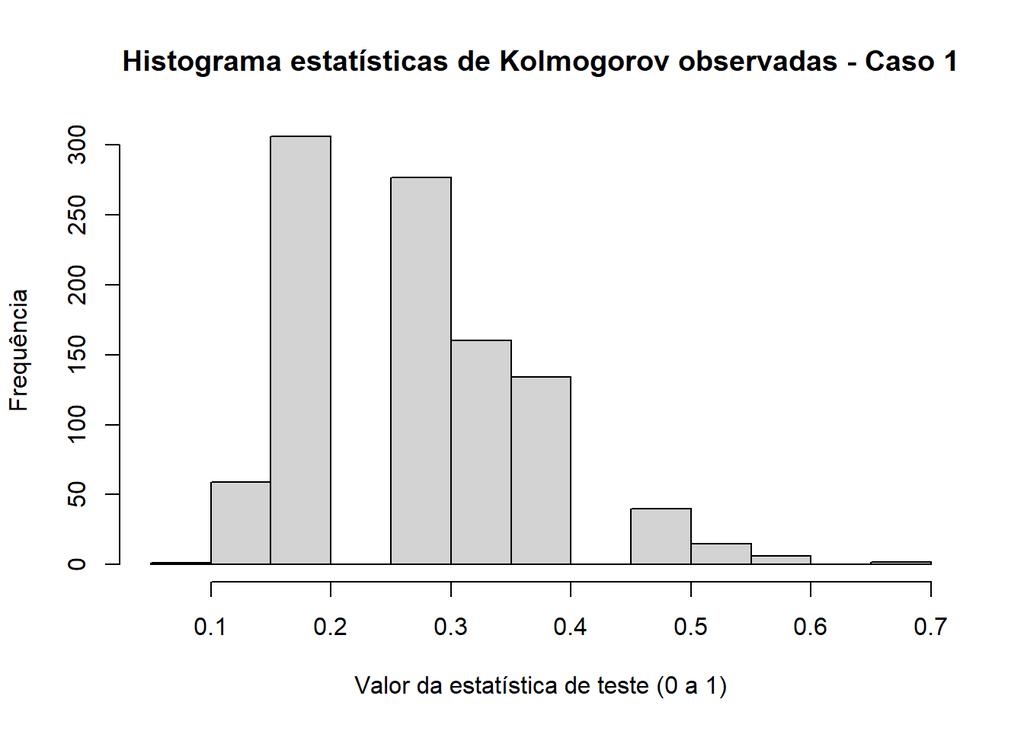

*Boxplot*

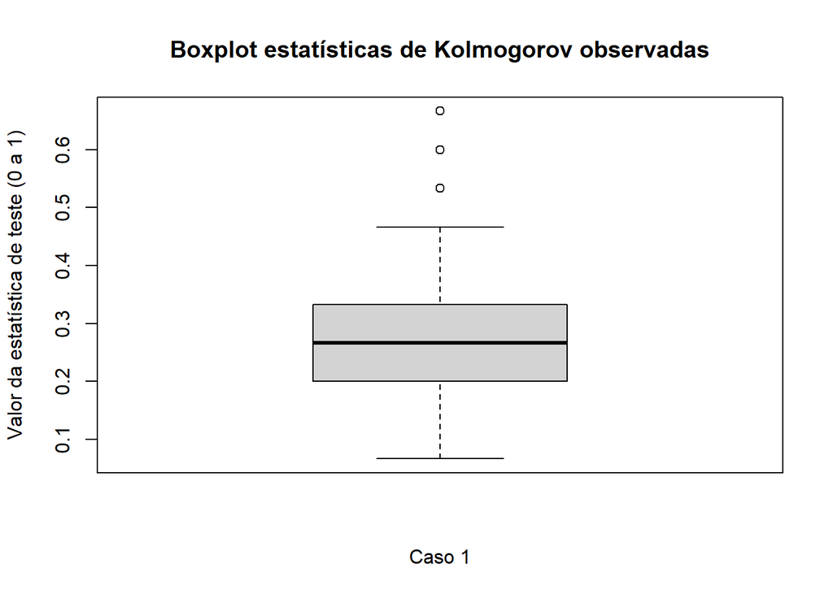

**CASO 2**

Proporção dentre as 1000 amostras do **CASO 2** cuja estatística de teste é maior ou igual ao valor tabelado

|  | 80% | 85% | 90% | 95% | 97,5% | 99% |
| --- | --- | --- | --- | --- | --- | --- |
| Proporção | 0.529 | 0.216 | 0.216 | 0.074 | 0.074 | 0.021 |

Histograma

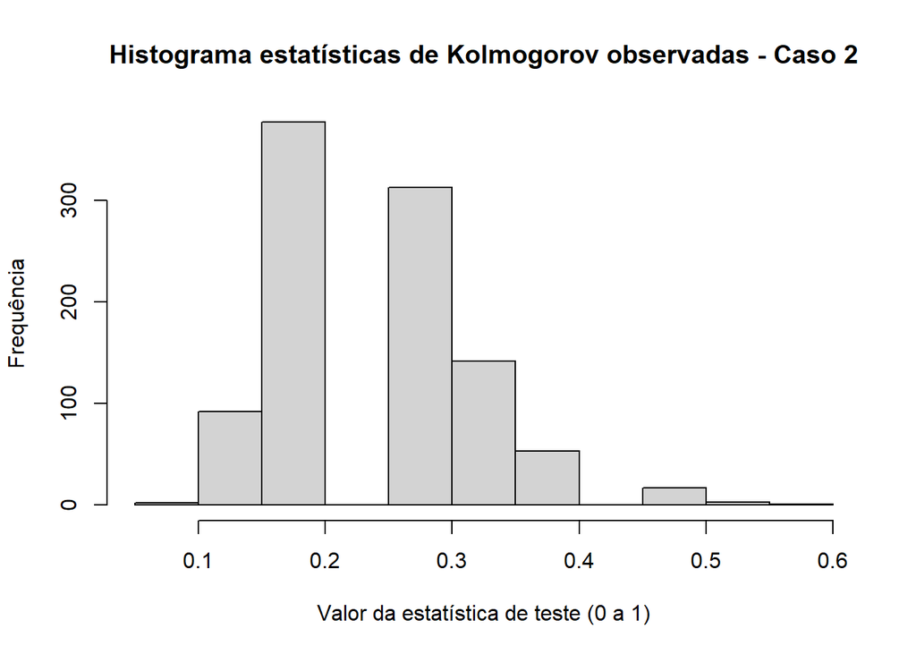

*Boxplot*

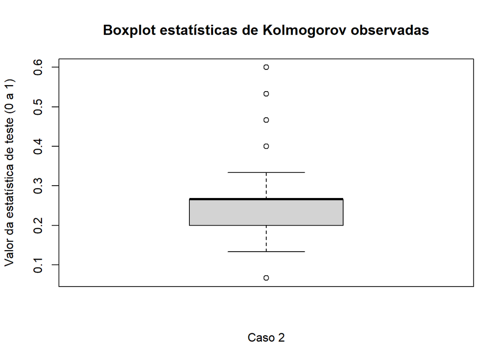

# **2.** Testes para normalidade: *Shapiro-Wilk* e *Anderson-Darling*

## Escolha 5 amostras geradas anteriormente, e teste normalidade utilizando *Shapiro-Wilk* e *Anderson-Darling*.

## Compare com os resultados anteriores e comente os resultados

Como nessa questão o número de testes é significativamente inferior, acredito ser apropriado apresentar os resultados um a um

**Testes *Shapiro-Wilk***

O primeiro teste *Shapiro-Wilk* observou estatística de teste **W=0.9265408**, com **p-valor=0.2421097**

O segundo teste *Shapiro-Wilk* observou estatística de teste **W=0.9678226**, com **p-valor=0.824602**

O terceiro teste *Shapiro-Wilk* observou estatística de teste **W=0.9406037**, com **p-valor=0.3900216**

O quarto teste *Shapiro-Wilk* observou estatística de teste **W=0.9315922**, com **p-valor=0.2882066**

O quinto teste *Shapiro-Wilk* observou estatística de teste **W=0.9583499**, com **p-valor=0.663745**

É bem direto inferir que, baseado nos valores **W** e **p-valor** encontrados, o teste de *Shapiro-Wilk* demonstra uma alta aderência entre a distribuição dos valores observados nas amostras sorteadas, com os valores esperados de uma distribuição normal.

**Testes *Anderson-Darling***

O primeiro teste *Anderson-Darling* observou estatística de teste **A=0.501817**, com **p-valor=0.1739694**

O segundo teste *Anderson-Darling* observou estatística de teste **A=0.1899323**, com **p-valor=0.8813322**

O terceiro teste *Anderson-Darling* observou estatística de teste **A=0.3759062**, com **p-valor=0.3655265**

O quarto teste *Anderson-Darling* observou estatística de teste **A=0.3871297**, com **p-valor=0.342802**

O quinto teste *Anderson-Darling* observou estatística de teste **A=0.2351962**, com **p-valor=0.746915**

Portanto, tanto os testes de *Kolmogorov* quanto os de *Anderson-Darling* demonstram talvez não serem os testes mais apropriados para se trabalhar com amostras de tamanho tão pequeno, apesar de serem muito úteis em amostras com tamanho maior.